# Végső porjekt

Jászai Tamás és Szutor Bálint

2020.01.16.

# Cél: League of Legends (LoL) mérkőzések eredményének előrejelzése

Az eredeti motívációt az volt, hogy a LoL egy digitális játék/(e-)sport, így a mérkőzésekről könnyebb real-time adatokat szerezni, mint nem digitális játékokról/sportokról (pl. futball, kosárlabda, stb.). Ez business szempontból azért érdekes, mert így egy jó előrejelző modell 1) segíthet real-time fogadások megkötésében, és igazán jól működő modellek esetében elméleti szinten pozitív várható értékű fogadásokat is köthetünk, illetve 2) segíthet a real-time fogadások árazásának kialakításába a fogadóirodák számára.

Sajnos nem tudtuk végül megoldani, hogy az adataink ne a mérkőzések végső statisztikáit tükrözzék (azaz, nem voltak pl. a meccs felénél összegyűjtött adataink, így nem tudtuk azt letesztelni, hogy a meccsek felének adatai alapján milyen pontossággal lehet előrejelezni a végeredményt). Emiatt csak a végső statisztikákból próbáltuk előrejelezni a meccsek kimenetelét, ami nem ad igazi választ a kérdésfeltevésünkre. Emiatt érdemesnek tartjuk a kérdésre való visszatérést a későbbiekben, megfelelő adathalmaz beszerzését követően.

Módszertan:

Többféle modellt használtunk. Az első részben megpróbáltuk a megfelelő változók kiválasztásával felépíteni a modellt (GLM, LVQ, RFE), később pedig kipróbáltunk egy számunkra új, PCR alapú modellt is, melyet az alábbi cikkben találtunk: https://www.sciencedirect.com/science/article/pii/S0167947318300562, itt a változóknak egy kombinációja lett volna használva.

Az volt az előzetes elképzelésünk, hogy a PCR alapú modell jobban fog teljesíteni. Ennek oka, hogy nagy korreláció az egyes változók értéke között, ezért a muiltikollinearitás problémáját jobban kezelő PCR alapú modellt előzetesen jobbnak vártuk.

Ezekről részletesebben alább beszámolunk.

# A projekt megvalósításának egyes lépései:

Adat keresés Felderítő adatelemzés Adat tisztítás Modellek illesztése, validációja

Ezekről egyesével részletesebb beszámoló alább található:

# Adat kereses

Mint korábban említettük, sajnos nem tudtuk a mérkőzések “köztes eredményeit” leíró adatokat találni. A felhasznált adatok forrása a Riot Games API, innen kértük le az adatokat egy Python kóddal, amit alább beillesztettünk. Azért a Riot Games API-ja elég korlátozott mennyiségű adat lekérését tette lehetővé, de más forrást sajnos nem találtunk. Emiatt csak néhány ezer mérkőzésről sikerült adatokat szereznünk. Pozitívum viszont, hogy sok változó (80+) szerepelt az adatbázisban.

```r
# Nem tudtuk kiexportálni HTML-be, amíg nem raktuk at R kód blokka, elnézést a gépemen sajnos elég sok furcsa R Studio hiba szembejön.

# import cassiopeia as cass
# import pandas as pd
# import time
#
# cass.set_riot_api_key("")
# players = [""]
#
# ids = []
# champions = []
# masteries = []
# sides = []
# sides = []
# win = []
# stats = []
# summonername = []
# date = []
#
# for name in players:
#     #Create data frame to populate with matches
#     playerdata = cass.get_summoner(name = name, region = "EUNE")
#     match = playerdata.match_history
#
#     for matchnum in range(len(match)):
#         print(matchnum, len(match))
#         time.sleep(0.1)
#         for sumnum in range(10):
#             if "fives" in match[matchnum].queue.name and "coop" not in match[matchnum].queue.name:
#                 try:
#                     date.append(match[matchnum].creation)
#                     ids.append(match[matchnum].id)
#                     champions.append(match[matchnum].participants[sumnum].champion.name)
#                     summonername.append(match[matchnum].participants[sumnum].summoner.name)
#                     a = match[matchnum].participants[sumnum].summoner.champion_masteries.filter(lambda cm: cm.champion.name == champions[matchnum])
#                     if len(a) > 0:
#                             masteries.append(a[0].points)
#                     else:
#                             masteries.append("NA")
#                     sides.append(match[matchnum].participants[sumnum].side)
#                     win.append(match[matchnum].red_team.win)
#                     stats.append(match[matchnum].participants[sumnum].stats.to_dict().values())
#                 except:
#                     mylists = [date, ids, champions, masteries, sides, win, stats]
#                     for currlist in mylists:
#                         if len(currlist) < len(ids):
#                             currlist.append("NA")
#
#     lists_together = list(zip(ids, summonername, champions, masteries, sides, win, stats))
#     df = pd.DataFrame(lists_together)
#
#     df.to_csv("LeaugeData" + name + ".csv")
#
#     ids = []
#     champions = []
#     masteries = []
#     sides = []
#     win = []
#     stats = []
#     summonername = []
#     date = []
```

# Packagek

```r
suppressPackageStartupMessages(library(data.table))
suppressPackageStartupMessages(library(ggplot2))
suppressPackageStartupMessages(library(magrittr))
suppressPackageStartupMessages(library(caret))
suppressPackageStartupMessages(library(tidyverse))
set.seed(1997)
```

# Adat tisztitas

Az adatokban találtunk: - sok ismétlődő információt, - hiányos adatsorokat, - nem numerikus változókat, - ID-ket, - valójában semmitmondó változókat: vagy már “kivették” a játékból és semmi szerepe nincsen, vagy gyakorlatilag sosem volt benne/volt szerepe.

Ezek kezelésére tisztítottuk az adathalmazt.

Továbbá az adathalmaz minden meccsre játékos szinten mutatja a statsiztikákat: egy meccset két 5 fős csapat játszik, és az adathalmazban egy-egy sor egy játékosnak felel meg (de meghatározható, hogy mely meccset melyik 10 játékos játszotta, és hogyan oszlottak meg a csapatok között: ugyanis egymást követő adatsorok alkotnak egy-egy meccset). Számunkra ugyanakkor hasznosabbak voltak a modellépítés szempontjából a csapatszintű adatok, ezért meccsenként a két csapatra aggregáltuk a csapatot alkotó játékosok egyéni adatait.

Az így kapott adattal az a probléma, hogy a LoL meccsek hossza nem jól definiált (meccsenként nagyon változó lehet), ugyanakkor erősen korrelál a megfigyelt változóinkkal (példa: meccs alatt okozott összes sebzés erősen korrelál a meccs hosszával). Emiatt egy változó valamilyen (pl. kis) értéke nem feltétlen jelentené azt, hogy a csapat rosszul teljesített, lehet, hogy csak a mérkőzés hosszát tükrözné. Mi ezt a problémát úgy kezeltük, hogy a meccsenként kiszámított, két csapatra külön-külön aggregált értékek különbségét vettük, és ezt használtuk a későbbi modellekben. Ennek az eljárásnak előnye, hogy amennyiben a csapatok tagjait azonos metódussal választja ki a játék (így teszi), akkor a különbségek várható értéke 0 lesz a meccs hosszától függetlenül. Természetesen a különbségek szórása erősen összefügg továbbra is a meccs hosszával, ezt a problémát nem sikerült jól kezelnünk.

Az alábbiakban rövidebb kommentekkel olvasható a kódunk:

```r
data <- fread("data/LeaugeDataMege_clean.csv", dec = ",")
full_data <- data

# Eldobtuk az olyan meccseket, ahol hiányzott valamilyen adat:
a <- data[, .N, IDs]
correct_ids <- a$IDs[a$N == 10]
data <- data[data[, IDs %in% correct_ids]]

# Csapatonként csoportosítás:
data_blue <- data[Sides == "Side.blue"]
data_red <- data[Sides == "Side.red"]

# Nem numerikus oszlopok elválsztása + használhatatlan adatok kidobálása:
non_numeric_columns <- c("SummonerName", "Champion", "Sides", "Redw", "item0", "item1", "item2", "item3", "item4", "item5", "item6", "playerScore1", "playerScore2", "playerScore3", "playerScore4", "playerScore5", "playerScore6", "playerScore7", "playerScore8", "playerScore9", "combatPlayerScore", "totalPlayerScore", "firstBloodAssist", "objectivePlayerScore", "totalScoreRank", "playerScore0", "sightWardsBoughtInGame", "unrealKills", "participantId", "perkSubStyle", "perkPrimaryStyle", "champLevel", "firstInhibitorAssist", "firstInhibitorKill", "firstBloodKill", "firstTowerAssist", "firstTowerKill", "quadraKills", "pentaKills")

data_blue[, c(non_numeric_columns):=NULL]
data_red[, c(non_numeric_columns):=NULL]

data_blue_sum <- aggregate(. ~IDs, data_blue, FUN = "sum") %>% data.table()
data_red_sum <- aggregate(. ~IDs, data_red, FUN = "sum") %>% data.table()

# Győzelem vektor
wins <- data[Sides == "Side.red", .(winner = sum(win)), by = list(IDs, Sides)]
used_ids <- data.table(cbind(wins$winner/5, data_red_sum$IDs))
names(used_ids) <- c("win", "IDs")

data_red_sum[,c("IDs", "win"):=NULL]
data_blue_sum[,c("IDs", "win"):=NULL]

# Csapatok közti különbségek kiszámítása:

diff <- data.table(as.matrix(data_red_sum) - as.matrix(data_blue_sum))

data <- cbind(used_ids, diff)
```

# Adat felfedezes

Ábrákon próbáltunk összefüggéeseket keresni. Fontos volt, hogy olyan változókat szerepeltessünk, amelyek nem részhalmaza egymásnak (ekkor nyilván van bizonyos összzefüggés). Néhányat ezekből szemléltet az alábbi kód:

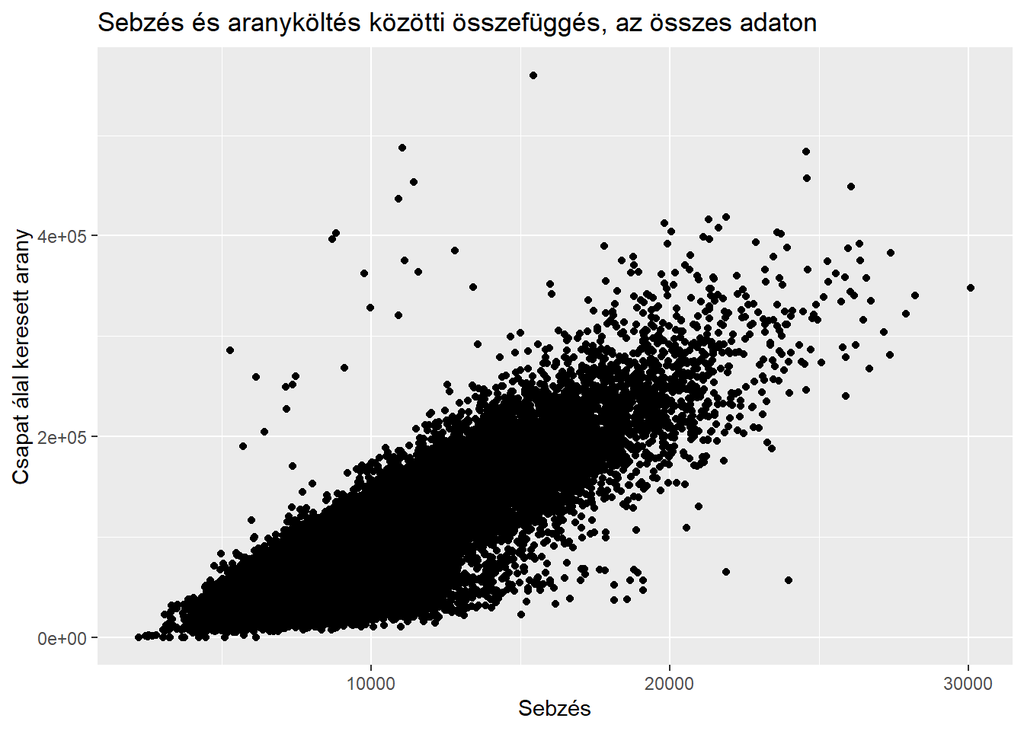

```r
ggplot(full_data, aes(x = goldEarned, y = totalDamageDealt)) +
  geom_point() +
  xlab("Sebzés") +
  ylab("Csapat álal keresett arany") +
  ggtitle("Sebzés és aranyköltés közötti összefüggés, az összes adaton")
```

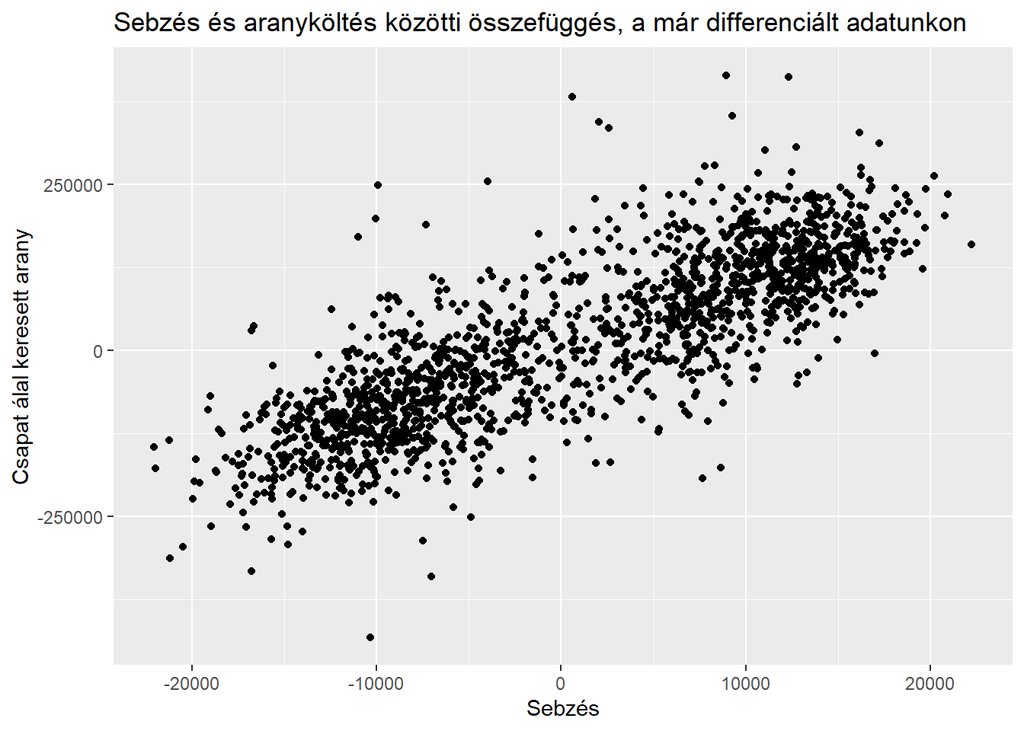

```r
ggplot(data, aes(x = goldEarned, y = totalDamageDealt)) +
  geom_point() +
  xlab("Sebzés") +
  ylab("Csapat álal keresett arany") +
  ggtitle("Sebzés és aranyköltés közötti összefüggés, a már differenciált adatunkon")
```

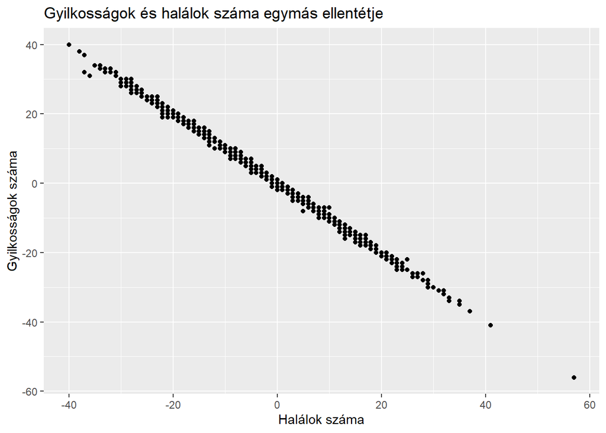

```r
# Látszódik a két ábrán, hogy ahol a full adatot használtuk, azaz ott, ahol nem a különbségét vettük az adatoknak, ott az adatok sokkal inkább szoródtak és kisebb volt a kapcsolat. Ez szerintünk azért van, mert a játék hossza torzít.


# Fontos azt is látni, hogy néhány változónk szinte csak egymás ellentétje de egyenlő, erre egy példa lehet:
ggplot(data, aes(x = deaths, y = kills)) +
  geom_point() +
  xlab("Halálok száma") +
  ylab("Gyilkosságok száma") +
  ggtitle("Gyilkosságok és halálok száma egymás ellentétje")
```

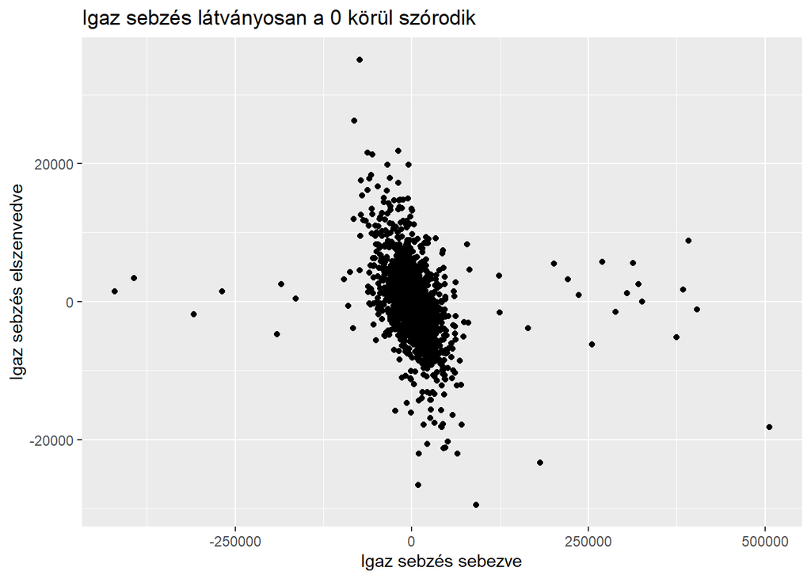

```r
# Vagy ami számomra érdekes volt, hogy például a true damage (ami egy olyan sebzés fajta a játékban, amit nem lehet levédeni), nagyon hasonló mindig a csapatok között és erősen a 0 körül szórodik
ggplot(data, aes(x = trueDamageDealt, y = trueDamageTaken)) +
  geom_point() +
  xlab("Igaz sebzés sebezve") +
  ylab("Igaz sebzés elszenvedve") +
  ggtitle("Igaz sebzés látványosan a 0 körül szórodik")
```

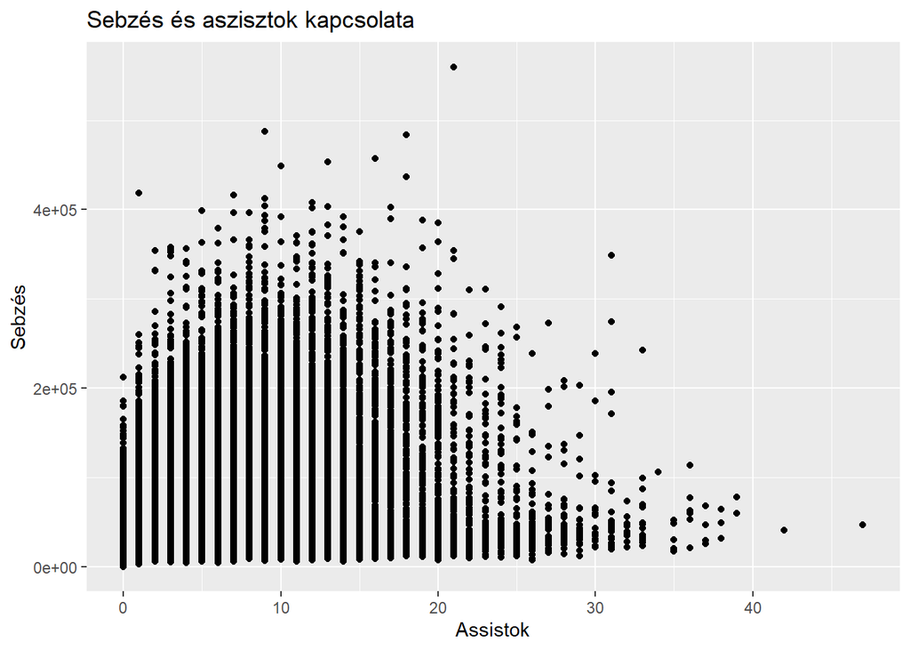

```r
# Ez az ábra különösen érdekes lehet és sokat elárul a játékról. Látszódik, hogy egy ideig ahogy nő az assistok száma (azaz, hogy hány gyilkosságban segítettünk egy csapattársunknak), úgy nő a sebzés is, azonban ez egy idő után megordul és csökkeni kezd. Ennek oka az lehet, hogy igazán sok assistot support karakterek szereznek, akik viszont nem sebeznek.
ggplot(full_data, aes(x = assists, y = totalDamageDealt)) +
  geom_point() +
  xlab("Assistok") +
  ylab("Sebzés") +
  ggtitle("Sebzés és aszisztok kapcsolata")
```

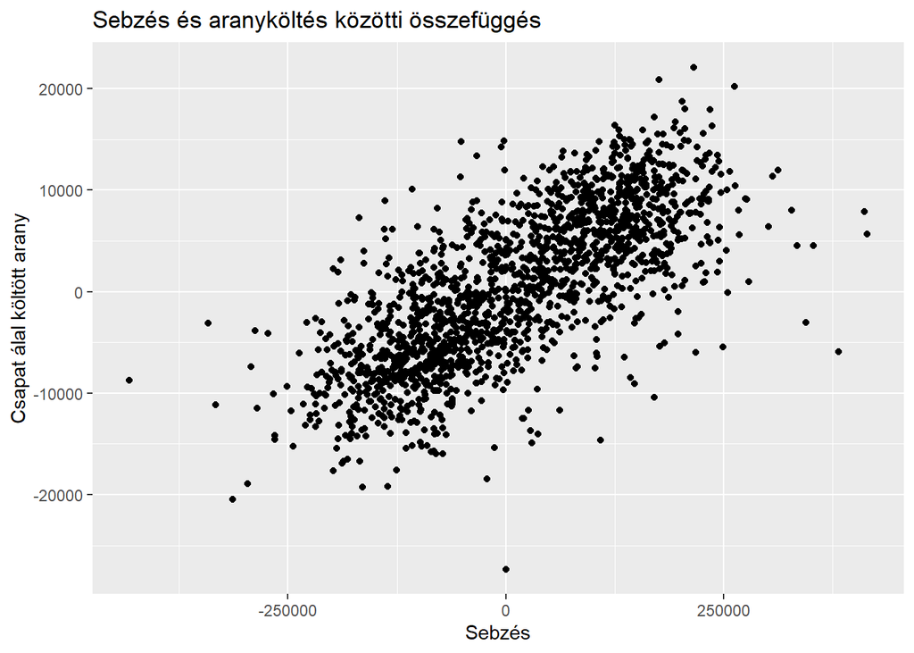

```r
# Mennyi aranyat költöttek, és ezzel mennyi sebzést tudtak okozni
ggplot(data, aes(x = totalDamageDealt, y = goldSpent)) +
  geom_point() +
  xlab("Sebzés")+
  ylab("Csapat álal költött arany") +
  ggtitle("Sebzés és aranyköltés közötti összefüggés")
```